# Тест №2

#### №1

Пусть предпочтения потребителя на множестве потребительских наборов полны и транзитивны. Какое/какие из следующих утверждений верны?

1. Относительно любых двух наборов из потребительского множества потребитель может сделать вывод, как они соотносятся с точки зрения их предпочтительности.
2. Разные кривые безразличия потребителя могут иметь точку пересечения.
3. Предпочтения потребителя таковы, что чем больше каждого блага в наборе, тем потребителю лучше.

#### №2

Пусть предпочтения потребителя на множестве потребительских наборов полны, транзитивны и непрерывны. Какое/какие из следующих утверждений верны?

1. Предпочтения потребителя представимы непрерывной функцией полезности.
2. Предпочтения потребителя строго выпуклы.
3. Если набор z лучше набора y, а набор y лучше набора x, то набор z лучше набора x.

#### №3

Пусть предпочтения потребителя на множестве потребительских наборов полны, транзитивны, непрерывны и строго монотонны. Какое/какие из следующих утверждений верны?

1. Кривые безразличия имеют неположительный наклон.
2. Чем дальше от начала координат расположена кривая безразличия, тем выше полезность потребителя.
3. Предпочтения потребителя выпуклы.

#### №4

Если предпочтения потребителя монотонны, то какой из следующих наборов хуже набора (18, 30)?

1. (18, 20)
2. (30, 18)
3. (10, 30)
4. (10, 18)
5. (30, 32)

#### №5

Тренер волейбольной команды отбирает игроков по результатам двух испытаний: владение мячом (ВМ) и общая физическая подготовка (ОФП), выставляя за каждое испытание оценку по 10-балльной шкале. Известно, что предпочтения тренера относительно игроков, характеризующихся баллами за испытания, строго монотонны. Предположим, игрок А получил 4 балла за ВМ и 6 баллов за ОФП, тогда однозначно можно сказать, что для тренера:

1. игрок, получивший 6 баллов за ВМ и 5 баллов за ОФП, лучше игрока А;
2. игрок, получивший 5 баллов за ВМ и 4 балла за ОФП, хуже игрока А;
3. игрок, получивший 6 баллов за ВМ и 4 балла за ОФП, эквивалентен игроку А;
4. игрок, получивший 3 балла за ВМ и 8 баллов за ОФП, лучше игрока А;
5. игрок, получивший 5 баллов за ВМ и 6 баллов за ОФП, лучше игрока А.

#### №6

По курсу математики предусмотрено две контрольные работы, за каждую из которых выставляется оценка по 10-балльной шкале. Студент А получил 4 балла за первую контрольную и 8 баллов за вторую, а студент В получил 10 баллов за первую контрольную и 6 баллов за вторую. Студент С каждую контрольную решил на 7 баллов. Известно, что предпочтения преподавателя относительно студентов, характеризующихся оценками за две контрольные работы, выпуклы и для него студенты А и В эквивалентны. Тогда с точки зрения преподавателя:

1. студент С лучше студента А, но хуже студента В;
2. студент А лучше студента С;
3. студент С не хуже и студента А, и студента В;
4. студент В лучше студента С;
5. студент С лучше студента В, но хуже студента А.

> В тестах 2.7 – 2.10 рассмотрите кривые безразличия, изображенные на рис. 1 (стрелкой указано направление роста благосостояния).

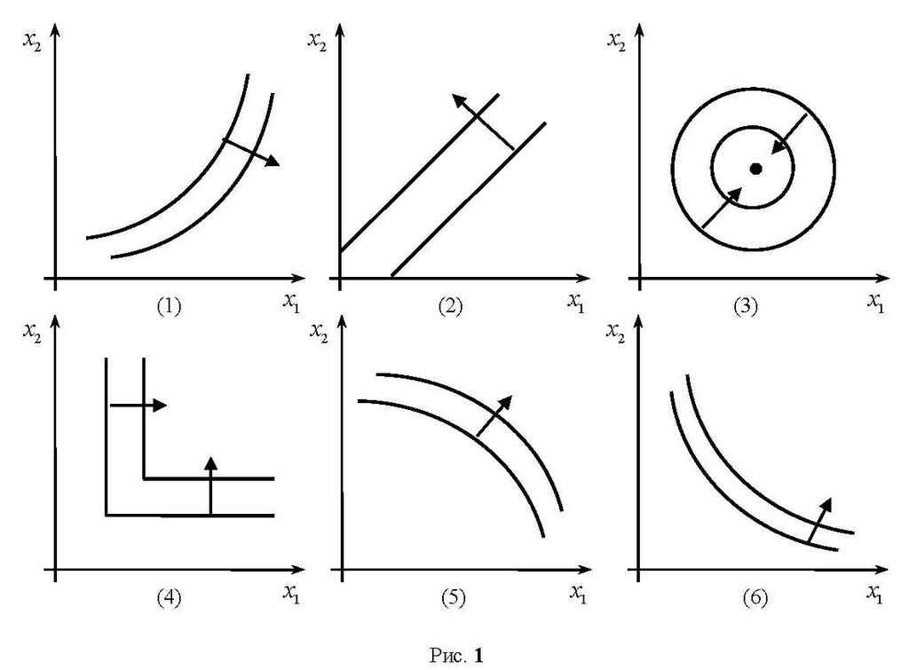

#### №7

На каком/каких рисунках изображены строго монотонные предпочтения?

1. только (6)
2. только (1), (5) и (6)
3. только (4), (5) и (6)
4. только (5) и (6)
5. только (1), (2), (4), (5) и (6)

#### №8

На каком/каких рисунках изображены монотонные предпочтения?

1. только (6)
2. только (1), (5) и (6)
3. только (4), (5) и (6)
4. только (5) и (6)
5. только (1), (2), (4), (5) и (6)

#### №9

На каком/каких рисунках изображены строго выпуклые предпочтения?

1. только (6)
2. только (3) и (6)
3. только (1), (5) и (6)
4. только (3)
5. только (1), (3), (5) и (6)

#### №10

На каком/каких рисунках изображены выпуклые предпочтения?

1. только (2) и (4)
2. только (5) и (6)
3. только (1), (5) и (6)
4. только (2), (3), (4) и (6)
5. только (1), (3), (5) и (6)

#### №11

Какое/какие из следующих утверждений верны?

1. Если предпочтения потребителя строго монотонны, то они монотонны.
2. Если предпочтения потребителя выпуклы, то они строго выпуклы.
3. Если предпочтения потребителя строго монотонны и набор x лучше набора y, то в наборе x каждого блага не меньше, и хотя бы одного блага больше, чем в наборе y.

#### №12

Пусть предпочтения потребителя представимы дифференцируемой функцией полезности. Какое/какие из следующих утверждений верны?

1. Предельная норма замещения характеризует расстояние между кривыми безразличия.
2. В любой точке на одной кривой безразличия предельная норма замещения постоянна.
3. Все наборы, лежащие на одной кривой безразличия, характеризуются одним и тем же уровнем полезности.

#### №13

Пусть предпочтения потребителя таковы, что он ценит оба блага и всегда готов заменить три единицы второго блага двумя единицами первого блага. Какое/какие из следующих утверждений верны?

1. Предпочтения потребителя выпуклы.
2. Предельная норма замещения второго блага первым равна 2/3.
3. Наборы (2, 3) и (3, 2) для потребителя эквивалентны.

#### №14

Пусть предпочтения потребителя описываются функцией полезности $u(x_1,x_2) = 3x_1x_2 + 2$. Какое/какие из следующих утверждений верны?

1. Наборы (2, 6) и (3, 4) для потребителя эквивалентны.
2. Предпочтения потребителя монотонны.
3. Набор (1, 5) лучше набора (2, 3).

#### №15

Пусть предпочтения потребителя описываются функцией полезности $u(x_1,x_2) = 3x_1x_2 + 2$. Тогда $MRS_{12}(x_1 = 4, x_2 = 8) =$

1. 0,5
2. 2
3. 98
4. 1,5
5. 6

#### №16

Пусть предпочтения потребителя описываются функцией полезности $u(x_1,x_2) = 3(x_1+x_2)$.Тогда уравнение кривой безразличия, проходящей через точку (3, 4), имеет вид:

1. $x_2 = 7 - x_1$
2. $x_2 = 21 - x_1$
3. $x_2 = x_1 - 7$
4. $x_2 = 21 - 3x_1$
5. $x_2 = 7 - 3x_1$

#### №17

Пусть предпочтения потребителя описываются функцией полезности $u(x_1,x_2) = 3(x_1+x_2)$. Какая из следующих функций полезности описывает те же предпочтения?

1. $u(x) = x_1x_2$
2. $u(x) = (x_1)^2 +(x_2)^2$
3. $u(x) = \frac{1}{x_1+x_2}$
4. $u(x) = \sqrt{x_1 + x_2}$
5. $u(x) = \sqrt{x_1} + \sqrt{x_2}$